# FPCA over trials

Xinyu Zhang

Load relevant libraries and set up.

```r
library(fda)
library(funData)
library(MFPCA)
library(tidyverse)
library(landmarkregUtils)
library(emmeans)
library(lme4)

Category.colors <- c(NB = "darkslategray", BB = "orangered")
```

Load data

```r
#ex <- 1 # change according to ex number
#raw_curves <- readRDS(file.path(data_dir, str_c("ex1D", ex, "rds", sep = '.'))) %>% ungroup() %>%
#  mutate(across(c(curveId, Category), ~ factor(.x)))

df <-  read.csv("productionFullTable.csv")

#change variables into correct data types
df$BB <- as.factor(df$BB)
df$Label <- as.factor(df$Label)
df$block <- as.factor(df$block)
df$gender <- as.factor(df$gender)
df$AF <- as.factor(df$AF)
df$subj <- as.character(df$subj)
df$seq <- as.numeric(df$seq)
df$F0Hz <- as.numeric(df$F0Hz)
df$F2Hz <- as.numeric(df$F2Hz)
df$F2Hz <- as.numeric(df$F2Hz)
df$F2Bark <- as.numeric(df$F2Bark)
df$F2Bark <- as.numeric(df$F2Bark)


#mutate a new sequence number that does not return to zero at the start of every block
df <-  read.csv("productionFullTable.csv") %>%
  mutate(
    seq = case_when(
      block == "2" ~ seq +54,
      block == "4" ~ seq +107,
      TRUE ~ seq
  )
)


#df %>%
  #filter(Label == "I") %>%
  #count(subj, seq, Label) %>%
 # filter(n > 0)

df <- df %>%
  #filter(Label == "I", block =="2") %>%
  #filter(Label == "I") %>% #all blocks
  distinct(subj, seq, .keep_all = TRUE)
```

Plot a few curves

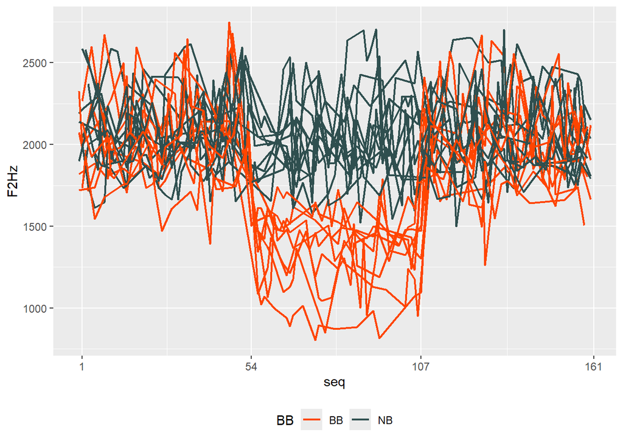

```r
# plot a few curves

subset_fileName <- df %>%
  distinct(subj) %>%
  slice_sample(n = 20)

curvedf<- df %>% inner_join(subset_fileName, by = "subj")


ggplot(data = curvedf) +
  aes(x = seq, y = F2Hz,, group = subj, color = BB) +
  geom_line(linewidth = 0.8) +
  scale_color_manual(values=Category.colors) +
  scale_x_continuous(breaks = c(1, 54, 107, 161))+
  #mytheme  +
  theme(legend.position = "bottom")
```

Compute FPCA

```r
# build a funData object (limiting it to only one of the vowels for simplicity)

funF2 <- df %>%
  long2irregFunData(id = "subj", time = "seq", value = "F2Hz") %>%
    as.funData()

# Compute FPCA
fpcaF2 <- PACE(funF2, npc = 4)

#df %>% filter(subj == "1")

#proportion of explained variance
fpcaF2$values / sum(fpcaF2$values)
```

```
## [1] 0.9870591581 0.0080951734 0.0046653720 0.0001802966
```

Plot PC curves

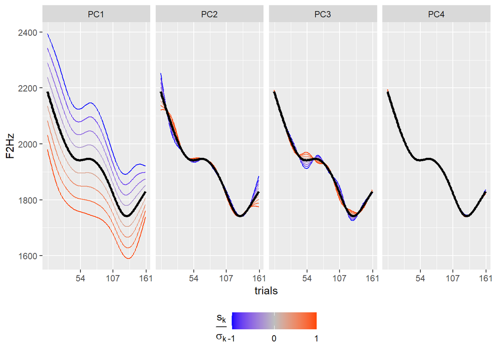

```r
# scores st. dev.
sdFun <- fpcaF2$values %>% sqrt()
# PC curves to be plotted
nPC <- 4
PCcurves <- expand_grid(PC = 1:nPC,
                        fractionOfStDev = seq(-1, 1, by=.25)) %>%
  group_by(PC, fractionOfStDev) %>%
  reframe(
    funData2long1(fpcaF2$mu + fractionOfStDev * sdFun[PC] * fpcaF2$functions[PC],
                  time = "seq", value = "F2Hz")
  )
# Plot
ggplot(PCcurves) +
  aes(x = seq, y = F2Hz, group = fractionOfStDev, color = fractionOfStDev) +
  geom_line() +
  scale_color_gradient2(low = "blue", mid = "grey", high = "orangered",
                        breaks = c(-1, 0 , 1)) +
  facet_wrap(~ PC, nrow = 1,
             labeller = labeller(PC = ~ str_glue("PC{.x}"))) +
  labs(color = expression(frac(s[k], sigma[k]))) +
  xlab("trials") +
  geom_line(data = PCcurves %>% filter(fractionOfStDev == 0), color = 'black', linewidth = 1.2) +
  scale_x_continuous(breaks = c(54, 107, 161))+
  #mytheme +
  theme(legend.position = "bottom")
```

Plot the mean curve

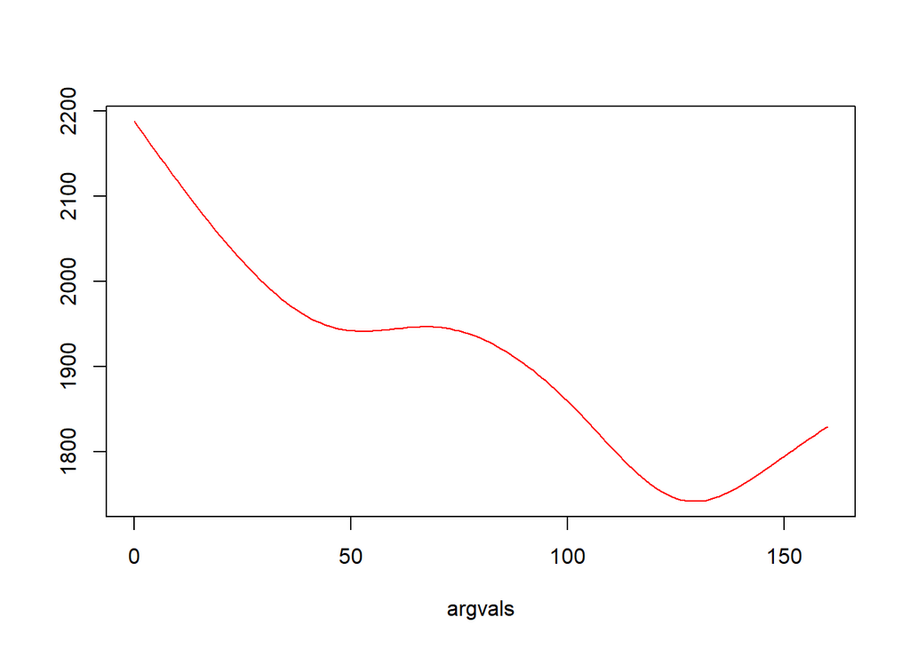

```r
# quick way (not ggplot)
fpcaF2$mu %>% plot()
```

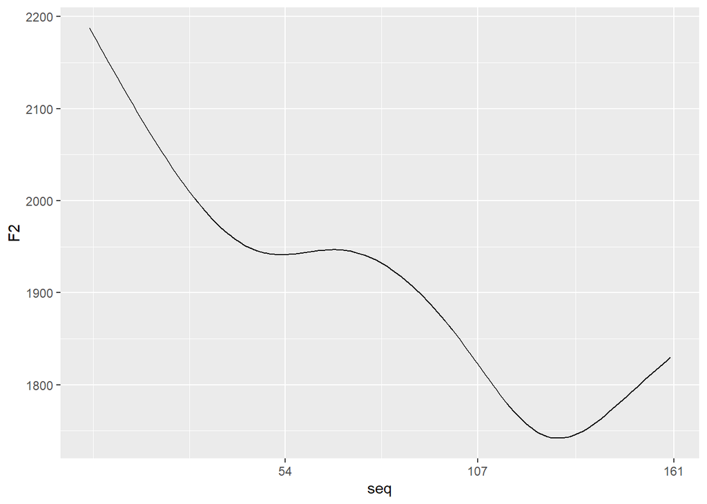

```r
# nicer way
fpcaF2$mu %>% funData2long1(time = "seq", value = "F2") %>% ggplot() +
  aes(x = seq, y = F2) +
  scale_x_continuous(breaks = c(54, 107, 161))+
  geom_line()
```

Plot PC1

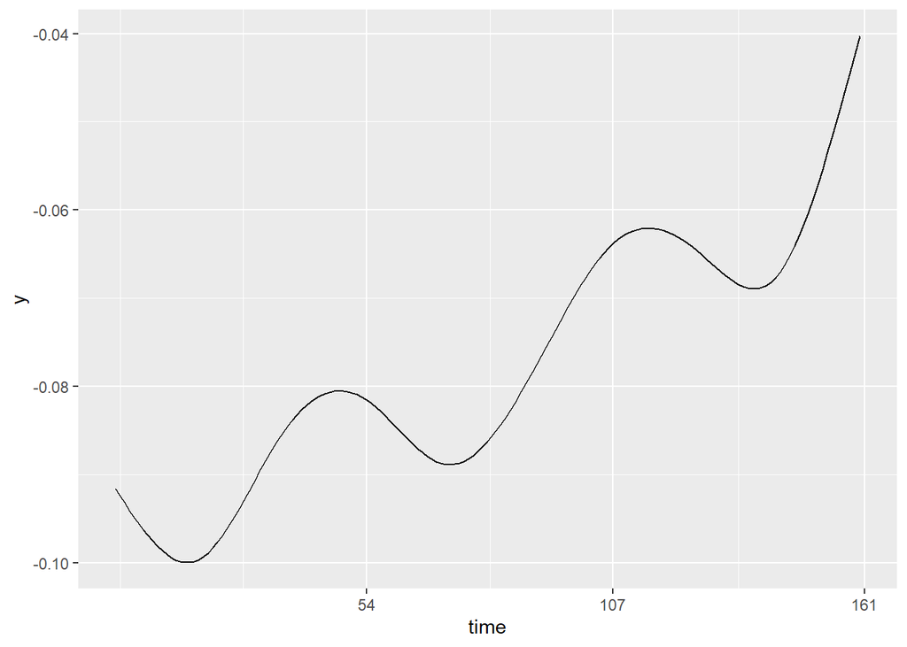

```r
fpcaF2$functions[1] %>% funData2long1(time = "time", value = "y") %>% ggplot() +
  aes(x = time, y = y) +
  scale_x_continuous(breaks = c(54, 107, 161))+
  geom_line()
```

Print the PC scores of the first few curves

```r
fpcaF2$scores %>% head()
```

```
##             [,1]       [,2]      [,3]       [,4]
## [1,]  1542.93949  -9.870843  41.49133 -3.7333457
## [2,] -4493.90344   5.788844 -17.29615 -1.7917594
## [3,]   -54.23105 -95.968957  49.38191  1.3219499
## [4,]   269.16371 -97.446908 -10.31541 -1.8129213
## [5,]  2286.65076  36.340446  49.69045 -0.1432137
## [6,] -3720.76451  32.283392  37.17306  3.9181240
```

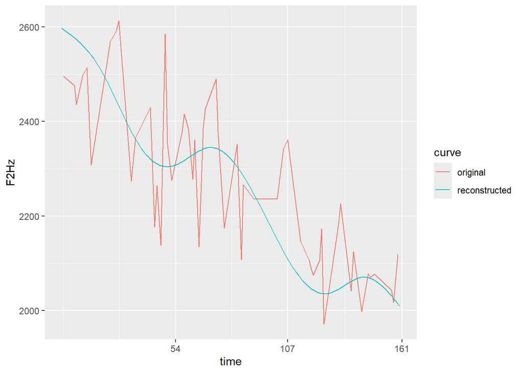

```r
orig_curve <- funF2[2] %>% funData2long1(value = "F2Hz")
rec_curve <- (fpcaF2$mu + fpcaF2$scores[2,1] * fpcaF2$functions[1]+
                fpcaF2$scores[2,2] * fpcaF2$functions[2]
                ) %>% funData2long1(value = "F2Hz")
# join the curves into one long format tibble and plot
bind_rows(orig_curve %>% mutate(curve = "original"),
          rec_curve %>% mutate(curve = "reconstructed")) %>%
  ggplot(aes(time, F2Hz, color = curve)) +
  scale_x_continuous(breaks = c(54, 107, 161))+
  geom_line()
```

Plot PC scores scatterplot

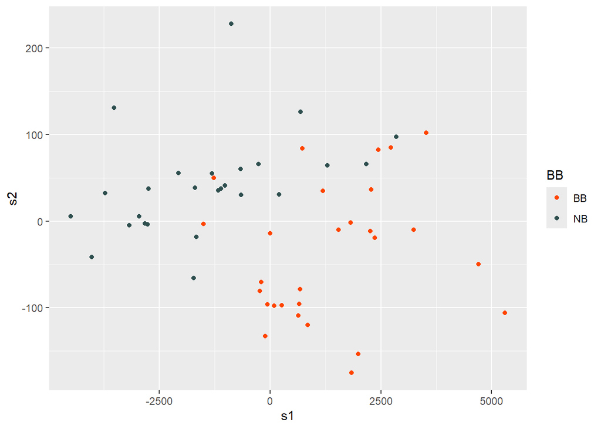

```r
PCscores <- fpcaF2$scores %>%
  `colnames<-`( paste0("s", 1:fpcaF2$npc)) %>%
  # above line means: colnames(fpcaF2$scores) <- paste0("s", 1:fpcaF2$npc) %>%
  as_tibble() %>%
  bind_cols(df %>% distinct(subj, BB, gender, AF), .)


# scatterplot PC scores s1 and s2 by Category
ggplot(PCscores) +
  aes(x = s1, y = s2, color = BB) +
  geom_point() +
  scale_color_manual(values=Category.colors) +
  #mytheme +
  theme(legend.position = "right")
```

Pick two random curves from the dataset, call them `curve1` and `curve2`. Plot the curves. Then mark the corresponding points on the scatterplot.

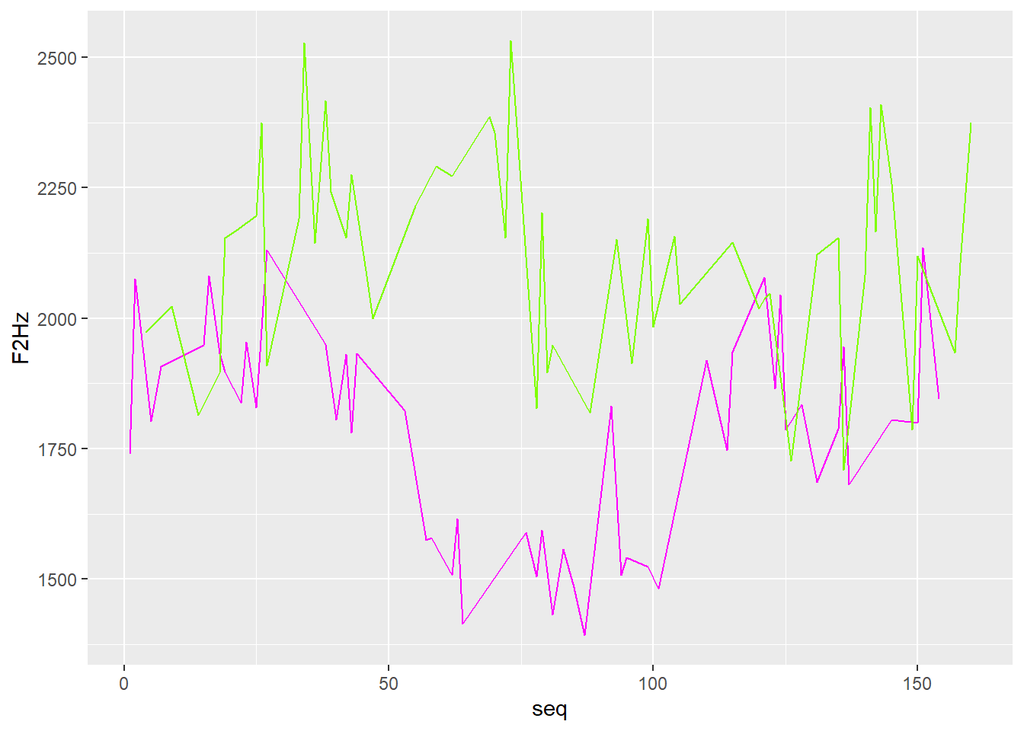

```r
id1 <- 4
id2 <- 35
curve1 <- df %>% filter(subj==id1)
curve2 <- df %>% filter(subj==id2)
ggplot(mapping = aes(seq, F2Hz)) +
  geom_line(data = curve1, color = "magenta") +
  geom_line(data = curve2, color = "chartreuse")
```

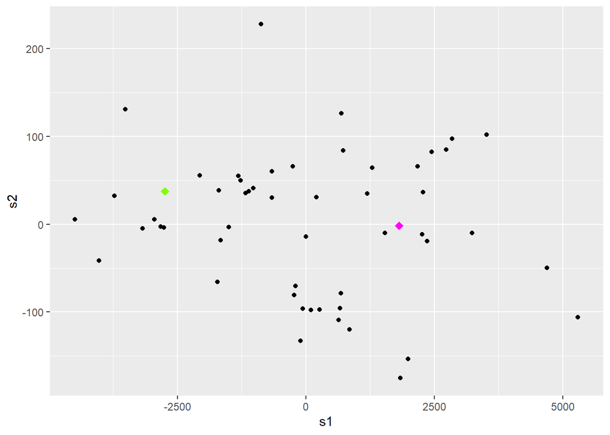

```r
ggplot(PCscores) +
  aes(x = s1, y = s2) +
  geom_point() +
  geom_point(data = PCscores %>% filter(subj==id1), color = "magenta", size = 3, shape = 18) +
  geom_point(data = PCscores %>% filter(subj==id2), color = "chartreuse", size = 3, shape = 18) +
  #mytheme +
  theme(legend.position = "right")
```

Construct a new curve based on `curve1` and `curve2`, call it `curveX`. The new curve is obtained by averaging the PC scores of `curve1` and `curve2`. Consider the first two PC scores. Plot `curveX`’s PC scores on the scatterplot. Plot `curveX` together with `curve1` and `curve2`.

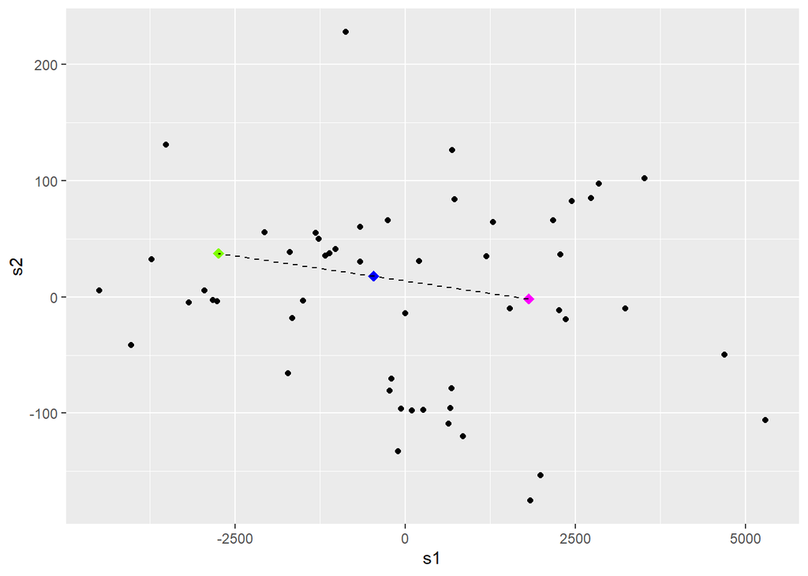

```r
scoresX <- PCscores %>% filter(subj %in% c(id1, id2)) %>% summarise(across(c(s1, s2), mean))
ggplot(PCscores) +
  aes(x = s1, y = s2) +
  geom_point() +
  geom_point(data = PCscores %>% filter(subj==id1), color = "magenta", size = 3, shape = 18) +
  geom_point(data = PCscores %>% filter(subj==id2), color = "chartreuse", size = 3, shape = 18) +
  geom_point(data = scoresX, color = "blue", size = 3, shape = 18) +
  geom_segment(x = PCscores %>% filter(subj==id1) %>% pull(s1),
               xend = PCscores %>% filter(subj==id2) %>% pull(s1),
               y = PCscores %>% filter(subj==id1) %>% pull(s2),
               yend = PCscores %>% filter(subj==id2) %>% pull(s2),
               linetype = "dashed") +
  #mytheme +
  theme(legend.position = "right")
```

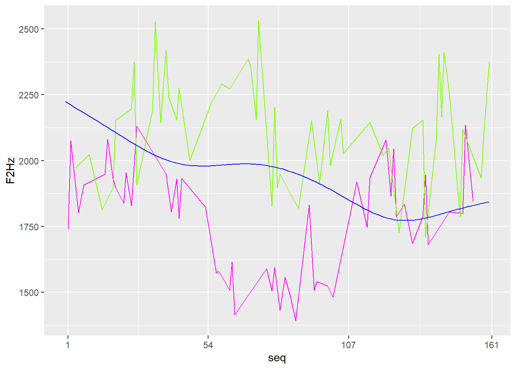

```r
curveX <- (
  fpcaF2$mu + (scoresX %>% pull(s1)) * fpcaF2$functions[1] +
    (scoresX %>% pull(s2)) * fpcaF2$functions[2]
) %>% funData2long1(time = "seq", value = "F2Hz")
ggplot(mapping = aes(seq, F2Hz)) +
  geom_line(data = curve1, color = "magenta") +
  geom_line(data = curve2, color = "chartreuse") +
  geom_line(data = curveX, color = "blue")+
  scale_x_continuous(breaks = c(1,54, 107, 161))
```

Reconstruct the first curve (first row of scores matrix) up to the first two PC scores (first two columns of scores matrix). Compare to original curve.

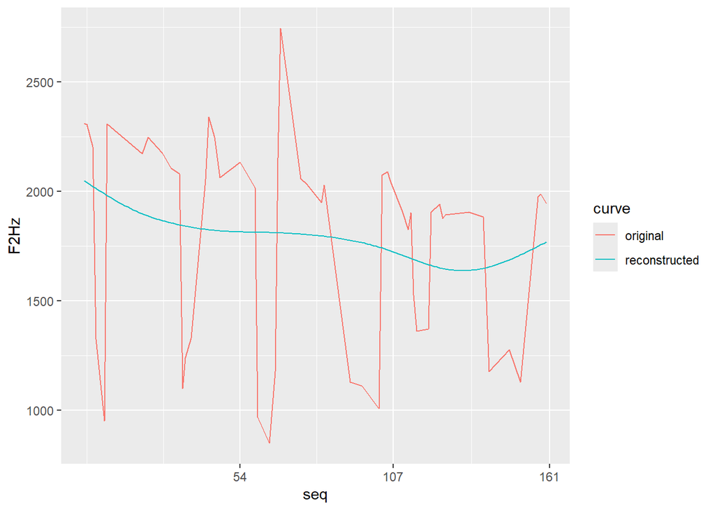

```r
orig_curve <- funF2[1] %>% funData2long1(time = "seq",value = "F2Hz")
rec_curve <- (fpcaF2$mu + fpcaF2$scores[1,1] * fpcaF2$functions[1] +
                fpcaF2$scores[1,2] * fpcaF2$functions[2]) %>% funData2long1(time = "seq", value = "F2Hz")
# join the curves into one long format tibble and plot
bind_rows(orig_curve %>% mutate(curve = "original"),
          rec_curve %>% mutate(curve = "reconstructed")) %>%
  ggplot(aes(seq, F2Hz, color = curve)) +
  scale_x_continuous(breaks = c(54, 107, 161))+
  geom_line()
```

Fit a regression model on s1

```r
#model for s1
s1mod <- lm (s1 ~ BB, data = PCscores)
emmeans(s1mod, pairwise ~BB)
```

```
## $emmeans
##  BB emmean  SE df lower.CL upper.CL
##  BB   1350 330 52      688     2013
##  NB  -1430 343 52    -2118     -743
##
## Confidence level used: 0.95
##
## $contrasts
##  contrast estimate  SE df t.ratio p.value
##  BB - NB      2780 476 52   5.844 <0.0001
```

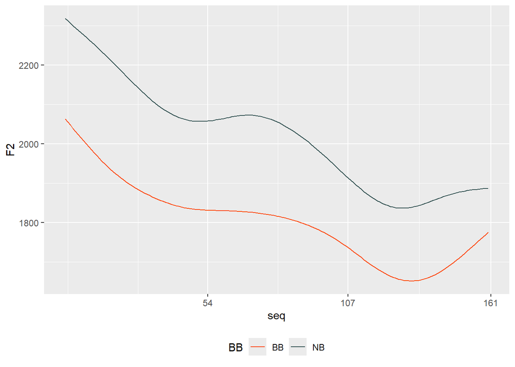

```r
#reconstruct predicted curves
emm <- emmeans (s1mod, pairwise ~ BB) $emmeans %>%
  as_tibble() %>%
  select(BB, emmean) %>%
  rename(s1 = emmean)

predCurvess1 <- emm %>%
  group_by(BB) %>%
  reframe(funData2long1(fpcaF2$mu + s1 * fpcaF2$functions[1])) %>%
  rename(seq = time, F2 = value)

ggplot(predCurvess1) +
  aes(seq, F2, color = BB)+
  geom_line()+
  scale_color_manual(values = Category.colors) +
  scale_x_continuous(breaks = c(54, 107, 161))+
  #mytheme +
  theme(legend.position = "bottom")
```

linear model on PC scores

```r
s1lm <- lm(s1 ~  BB * AF + gender, data = PCscores)
summary(s1lm)
```

```
##
## Call:
## lm(formula = s1 ~ BB * AF + gender, data = PCscores)
##
## Residuals:
##     Min      1Q  Median      3Q     Max
## -2578.5  -835.0    88.0   973.4  3209.4
##
## Coefficients:
##             Estimate Std. Error t value Pr(>|t|)
## (Intercept)   1033.6      366.2   2.823  0.00687 **
## BBNB         -2902.0      501.4  -5.788 4.96e-07 ***
## AFMN          -472.3      509.9  -0.926  0.35879
## genderM       2999.9      496.7   6.040 2.03e-07 ***
## BBNB:AFMN      425.2      721.4   0.589  0.55828
## ---
## Signif. codes:  0 '***' 0.001 '**' 0.01 '*' 0.05 '.' 0.1 ' ' 1
##
## Residual standard error: 1322 on 49 degrees of freedom
## Multiple R-squared:  0.6741, Adjusted R-squared:  0.6475
## F-statistic: 25.34 on 4 and 49 DF,  p-value: 2.057e-11
```

Plot the mean curve, then add one SD of s1 to it, on top of it, substract an SD of S1, to see what the first PC does

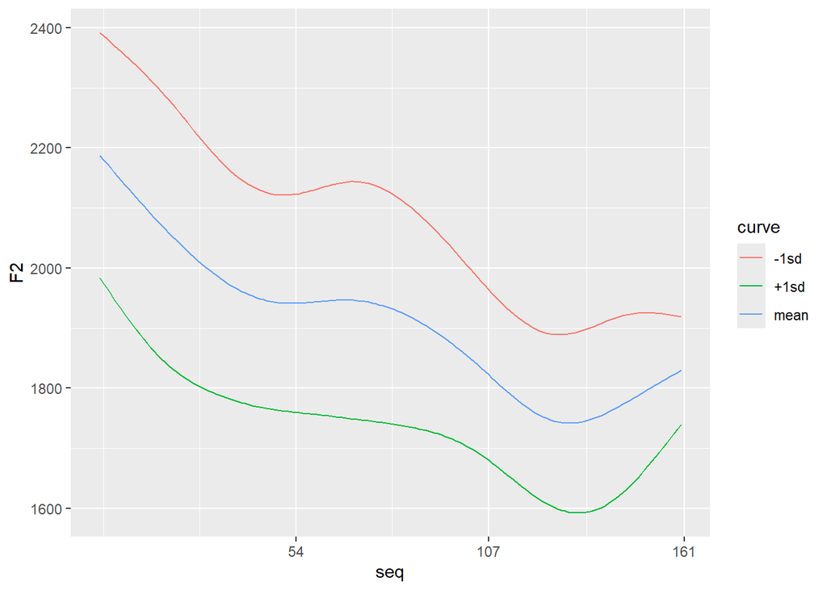

```r
#the mean curve
meancurve<- fpcaF2$mu %>% funData2long1(time = "seq", value = "F2") #%>% ggplot() +
  #aes(x = seq, y = F2) +
  #scale_x_continuous(breaks = c(54, 107, 161))+
  #geom_line()

#the mean curve with 1sd of s1 added
#plus1sdcurve <- fpcaF2$mu %>%funData2long1(time = "seq", value = "F2") %>%
  #mutate(F2 = F2 + sd(PCscores$s1))#%>% ggplot() +
  #aes(x = seq, y = F2) +
  #scale_x_continuous(breaks = c(54, 107, 161))+
  #geom_line()


sd1 <- fpcaF2$mu + 1*sd(PCscores$s1)*fpcaF2$functions[1]

plus1sdcurve <- sd1%>% funData2long1(time = "seq", value = "F2")

sd_1 <- fpcaF2$mu - 1*sd(PCscores$s1)*fpcaF2$functions[1]

minus1sdcurve <- sd_1%>% funData2long1(time = "seq", value = "F2")

# join the curves into one long format tibble and plot
bind_rows(meancurve %>% mutate(curve = "mean"),
          plus1sdcurve %>% mutate(curve = "+1sd"),
          minus1sdcurve %>% mutate(curve = "-1sd")) %>%
  ggplot(aes(seq, F2, color = curve)) +
  scale_x_continuous(breaks = c(54, 107, 161))+
  geom_line()
```

```r
#maybe it shouldn't be the mean curve? Check Gubian
```

# FPCA over trials

Xinyu Zhang

Load relevant libraries and set up.

```r
library(fda)
library(funData)
library(MFPCA)
library(tidyverse)
library(landmarkregUtils)
library(emmeans)
library(lme4)

Category.colors <- c(NB = "darkslategray", BB = "orangered")
```

Load data

```r
#ex <- 1 # change according to ex number
#raw_curves <- readRDS(file.path(data_dir, str_c("ex1D", ex, "rds", sep = '.'))) %>% ungroup() %>%
#  mutate(across(c(curveId, Category), ~ factor(.x)))

df <-  read.csv("productionFullTable.csv")

#change variables into correct data types
df$BB <- as.factor(df$BB)
df$Label <- as.factor(df$Label)
df$block <- as.factor(df$block)
df$gender <- as.factor(df$gender)
df$AF <- as.factor(df$AF)
df$subj <- as.character(df$subj)
df$seq <- as.numeric(df$seq)
df$F0Hz <- as.numeric(df$F0Hz)
df$F2Hz <- as.numeric(df$F2Hz)
df$F2Hz <- as.numeric(df$F2Hz)
df$F2Bark <- as.numeric(df$F2Bark)
df$F2Bark <- as.numeric(df$F2Bark)


#mutate a new sequence number that does not return to zero at the start of every block
df <-  read.csv("productionFullTable.csv") %>%
  mutate(
    seq = case_when(
      block == "2" ~ seq +54,
      block == "4" ~ seq +107,
      TRUE ~ seq
  )
)


#df %>%
  #filter(Label == "I") %>%
  #count(subj, seq, Label) %>%
 # filter(n > 0)

df <- df %>%
  #filter(Label == "I", block =="2") %>%
  #filter(Label == "I") %>% #all blocks
  distinct(subj, seq, .keep_all = TRUE)
```

Plot a few curves

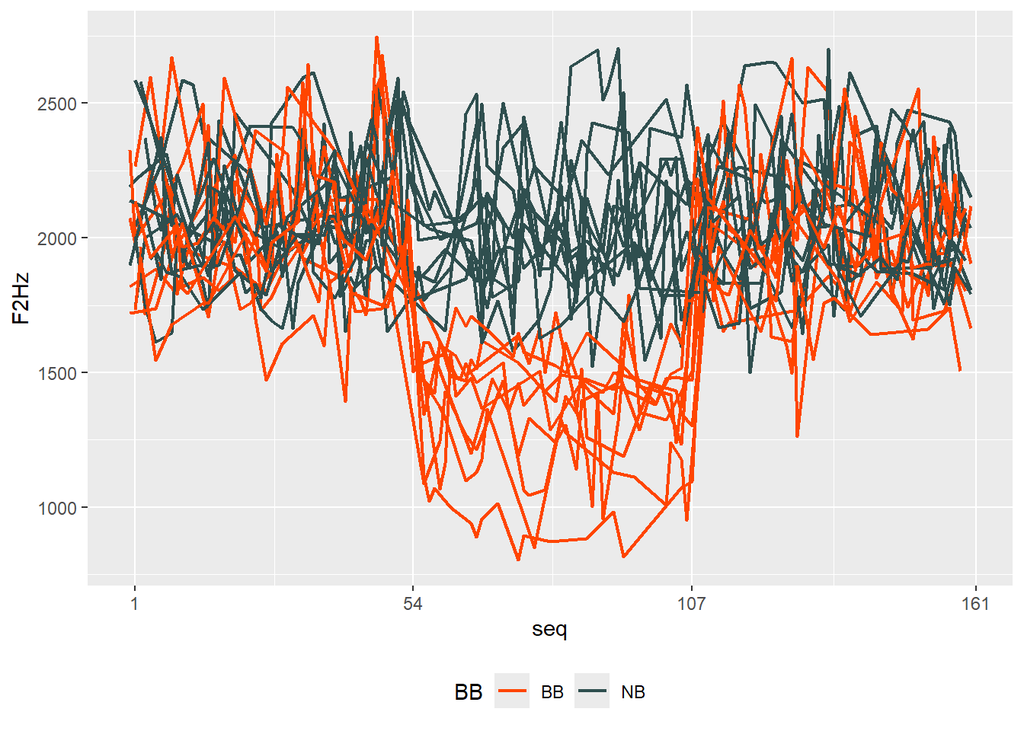

```r
# plot a few curves

subset_fileName <- df %>%
  distinct(subj) %>%
  slice_sample(n = 20)

curvedf<- df %>% inner_join(subset_fileName, by = "subj")


ggplot(data = curvedf) +
  aes(x = seq, y = F2Hz,, group = subj, color = BB) +
  geom_line(linewidth = 0.8) +
  scale_color_manual(values=Category.colors) +
  scale_x_continuous(breaks = c(1, 54, 107, 161))+
  #mytheme  +
  theme(legend.position = "bottom")
```

Compute FPCA

```r
# build a funData object (limiting it to only one of the vowels for simplicity)

funF2 <- df %>%
  long2irregFunData(id = "subj", time = "seq", value = "F2Hz") %>%
    as.funData()

# Compute FPCA
fpcaF2 <- PACE(funF2, npc = 4)

#df %>% filter(subj == "1")

#proportion of explained variance
fpcaF2$values / sum(fpcaF2$values)
```

```
## [1] 0.9870591581 0.0080951734 0.0046653720 0.0001802966
```

Plot PC curves

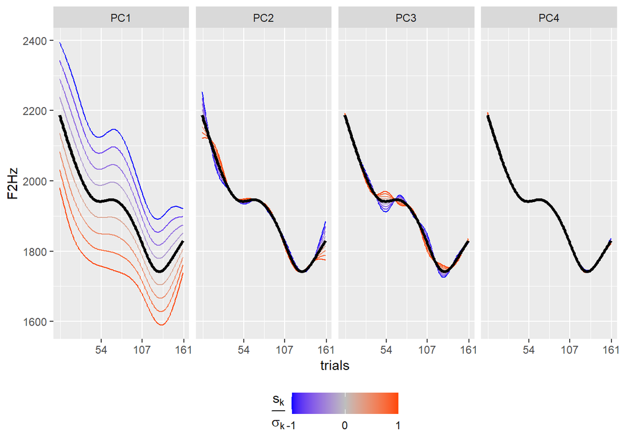

```r
# scores st. dev.
sdFun <- fpcaF2$values %>% sqrt()
# PC curves to be plotted
nPC <- 4
PCcurves <- expand_grid(PC = 1:nPC,
                        fractionOfStDev = seq(-1, 1, by=.25)) %>%
  group_by(PC, fractionOfStDev) %>%
  reframe(
    funData2long1(fpcaF2$mu + fractionOfStDev * sdFun[PC] * fpcaF2$functions[PC],
                  time = "seq", value = "F2Hz")
  )
# Plot
ggplot(PCcurves) +
  aes(x = seq, y = F2Hz, group = fractionOfStDev, color = fractionOfStDev) +
  geom_line() +
  scale_color_gradient2(low = "blue", mid = "grey", high = "orangered",
                        breaks = c(-1, 0 , 1)) +
  facet_wrap(~ PC, nrow = 1,
             labeller = labeller(PC = ~ str_glue("PC{.x}"))) +
  labs(color = expression(frac(s[k], sigma[k]))) +
  xlab("trials") +
  geom_line(data = PCcurves %>% filter(fractionOfStDev == 0), color = 'black', linewidth = 1.2) +
  scale_x_continuous(breaks = c(54, 107, 161))+
  #mytheme +
  theme(legend.position = "bottom")
```

Plot the mean curve

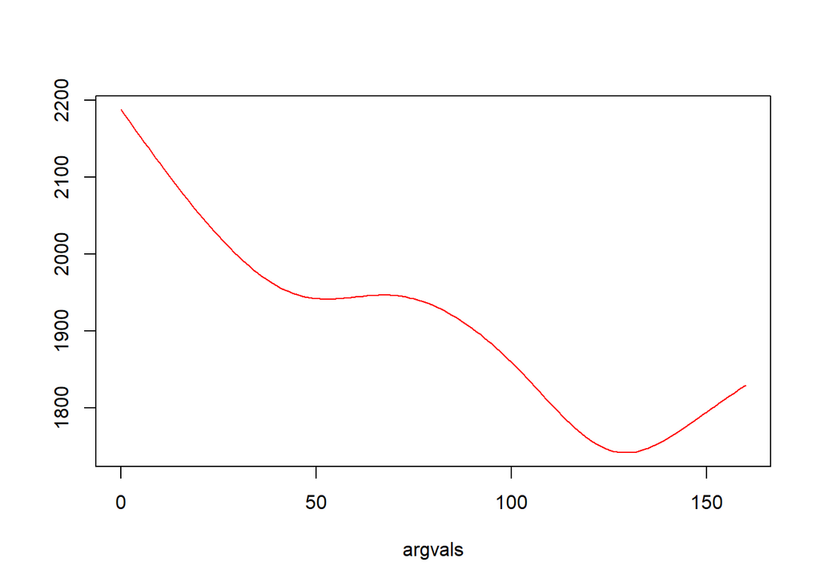

```r
# quick way (not ggplot)
fpcaF2$mu %>% plot()
```

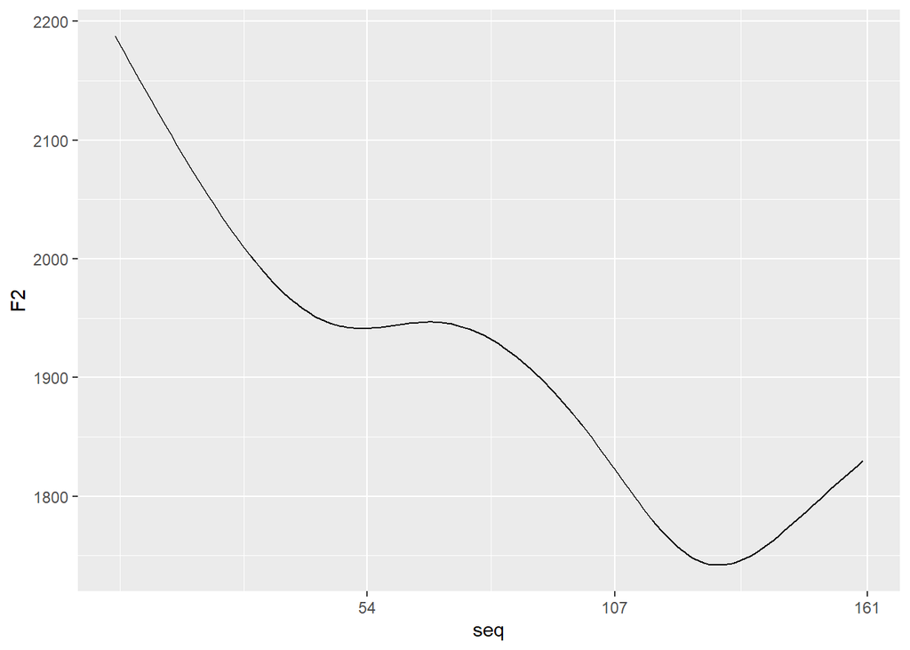

```r
# nicer way
fpcaF2$mu %>% funData2long1(time = "seq", value = "F2") %>% ggplot() +
  aes(x = seq, y = F2) +
  scale_x_continuous(breaks = c(54, 107, 161))+
  geom_line()
```

Plot PC1

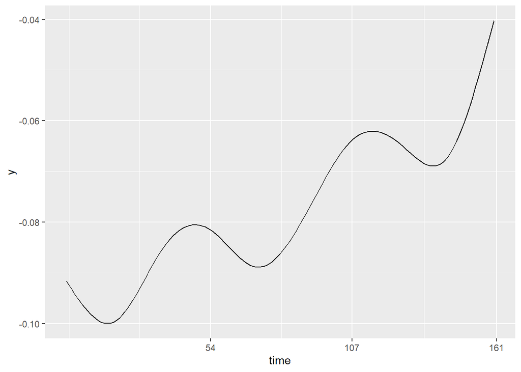

```r
fpcaF2$functions[1] %>% funData2long1(time = "time", value = "y") %>% ggplot() +
  aes(x = time, y = y) +
  scale_x_continuous(breaks = c(54, 107, 161))+
  geom_line()
```

Print the PC scores of the first few curves

```r
fpcaF2$scores %>% head()
```

```
##             [,1]       [,2]      [,3]       [,4]
## [1,]  1542.93949  -9.870843  41.49133 -3.7333457
## [2,] -4493.90344   5.788844 -17.29615 -1.7917594
## [3,]   -54.23105 -95.968957  49.38191  1.3219499
## [4,]   269.16371 -97.446908 -10.31541 -1.8129213
## [5,]  2286.65076  36.340446  49.69045 -0.1432137
## [6,] -3720.76451  32.283392  37.17306  3.9181240
```

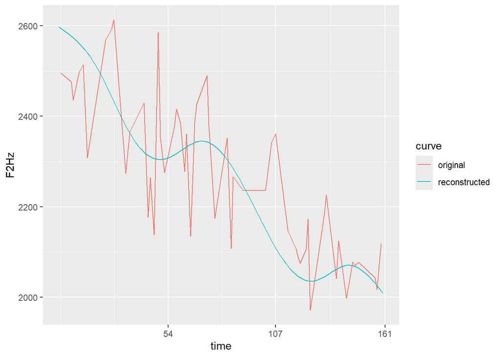

```r
orig_curve <- funF2[2] %>% funData2long1(value = "F2Hz")
rec_curve <- (fpcaF2$mu + fpcaF2$scores[2,1] * fpcaF2$functions[1]+
                fpcaF2$scores[2,2] * fpcaF2$functions[2]
                ) %>% funData2long1(value = "F2Hz")
# join the curves into one long format tibble and plot
bind_rows(orig_curve %>% mutate(curve = "original"),
          rec_curve %>% mutate(curve = "reconstructed")) %>%
  ggplot(aes(time, F2Hz, color = curve)) +
  scale_x_continuous(breaks = c(54, 107, 161))+
  geom_line()
```

Plot PC scores scatterplot

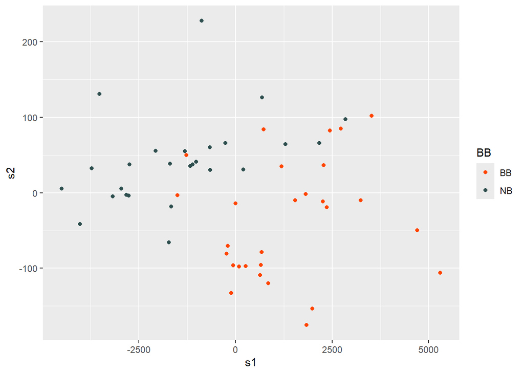

```r
PCscores <- fpcaF2$scores %>%
  `colnames<-`( paste0("s", 1:fpcaF2$npc)) %>%
  # above line means: colnames(fpcaF2$scores) <- paste0("s", 1:fpcaF2$npc) %>%
  as_tibble() %>%
  bind_cols(df %>% distinct(subj, BB, gender, AF), .)


# scatterplot PC scores s1 and s2 by Category
ggplot(PCscores) +
  aes(x = s1, y = s2, color = BB) +
  geom_point() +
  scale_color_manual(values=Category.colors) +
  #mytheme +
  theme(legend.position = "right")
```

Pick two random curves from the dataset, call them `curve1` and `curve2`. Plot the curves. Then mark the corresponding points on the scatterplot.

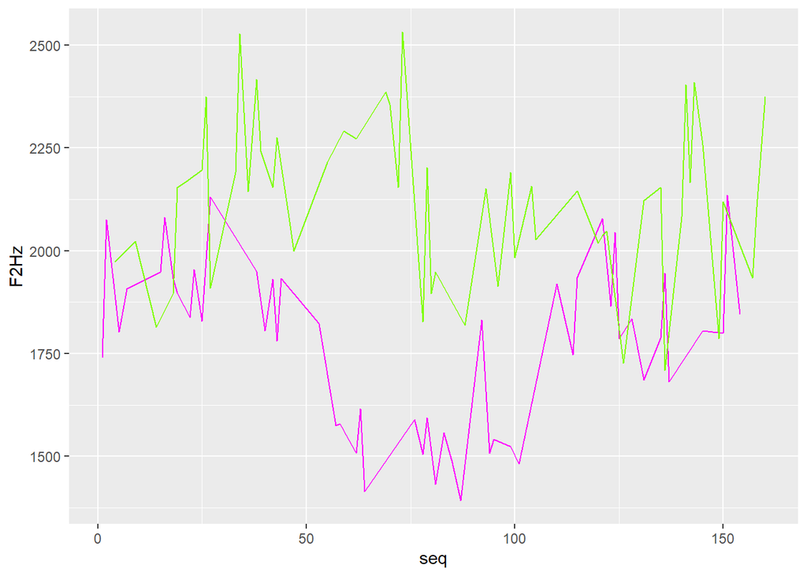

```r
id1 <- 4
id2 <- 35
curve1 <- df %>% filter(subj==id1)
curve2 <- df %>% filter(subj==id2)
ggplot(mapping = aes(seq, F2Hz)) +
  geom_line(data = curve1, color = "magenta") +
  geom_line(data = curve2, color = "chartreuse")
```

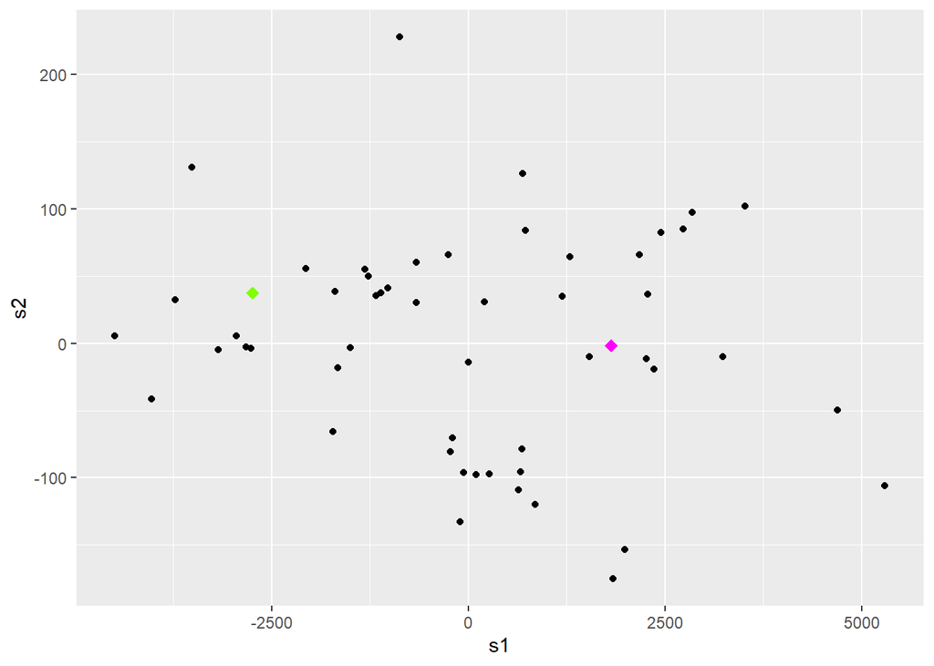

```r
ggplot(PCscores) +
  aes(x = s1, y = s2) +
  geom_point() +
  geom_point(data = PCscores %>% filter(subj==id1), color = "magenta", size = 3, shape = 18) +
  geom_point(data = PCscores %>% filter(subj==id2), color = "chartreuse", size = 3, shape = 18) +
  #mytheme +
  theme(legend.position = "right")
```

Construct a new curve based on `curve1` and `curve2`, call it `curveX`. The new curve is obtained by averaging the PC scores of `curve1` and `curve2`. Consider the first two PC scores. Plot `curveX`’s PC scores on the scatterplot. Plot `curveX` together with `curve1` and `curve2`.

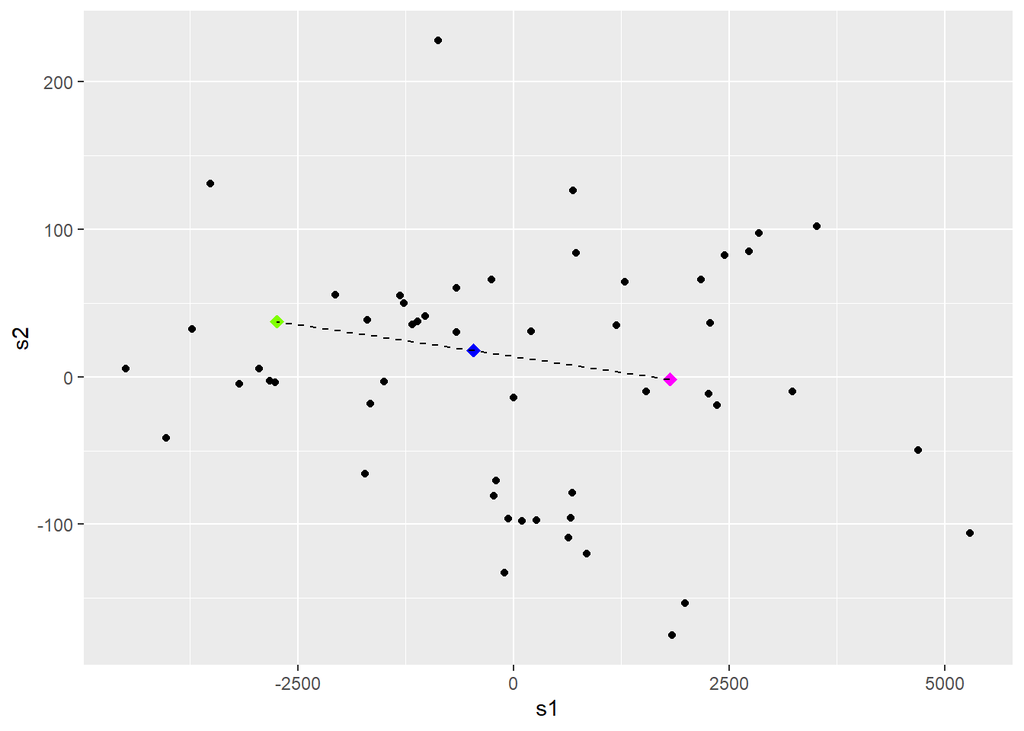

```r
scoresX <- PCscores %>% filter(subj %in% c(id1, id2)) %>% summarise(across(c(s1, s2), mean))
ggplot(PCscores) +
  aes(x = s1, y = s2) +
  geom_point() +
  geom_point(data = PCscores %>% filter(subj==id1), color = "magenta", size = 3, shape = 18) +
  geom_point(data = PCscores %>% filter(subj==id2), color = "chartreuse", size = 3, shape = 18) +
  geom_point(data = scoresX, color = "blue", size = 3, shape = 18) +
  geom_segment(x = PCscores %>% filter(subj==id1) %>% pull(s1),
               xend = PCscores %>% filter(subj==id2) %>% pull(s1),
               y = PCscores %>% filter(subj==id1) %>% pull(s2),
               yend = PCscores %>% filter(subj==id2) %>% pull(s2),
               linetype = "dashed") +
  #mytheme +
  theme(legend.position = "right")
```

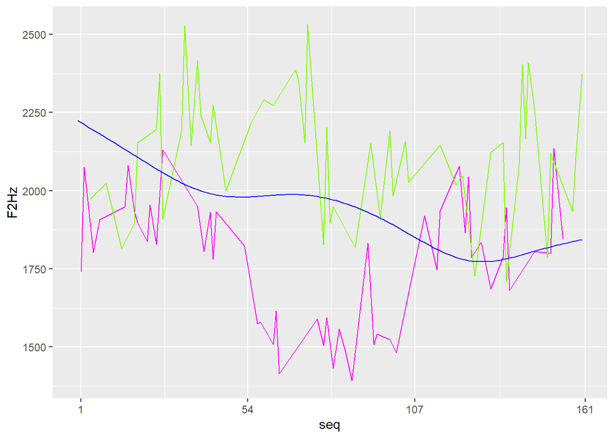

```r
curveX <- (
  fpcaF2$mu + (scoresX %>% pull(s1)) * fpcaF2$functions[1] +
    (scoresX %>% pull(s2)) * fpcaF2$functions[2]
) %>% funData2long1(time = "seq", value = "F2Hz")
ggplot(mapping = aes(seq, F2Hz)) +
  geom_line(data = curve1, color = "magenta") +
  geom_line(data = curve2, color = "chartreuse") +
  geom_line(data = curveX, color = "blue")+
  scale_x_continuous(breaks = c(1,54, 107, 161))
```

Reconstruct the first curve (first row of scores matrix) up to the first two PC scores (first two columns of scores matrix). Compare to original curve.

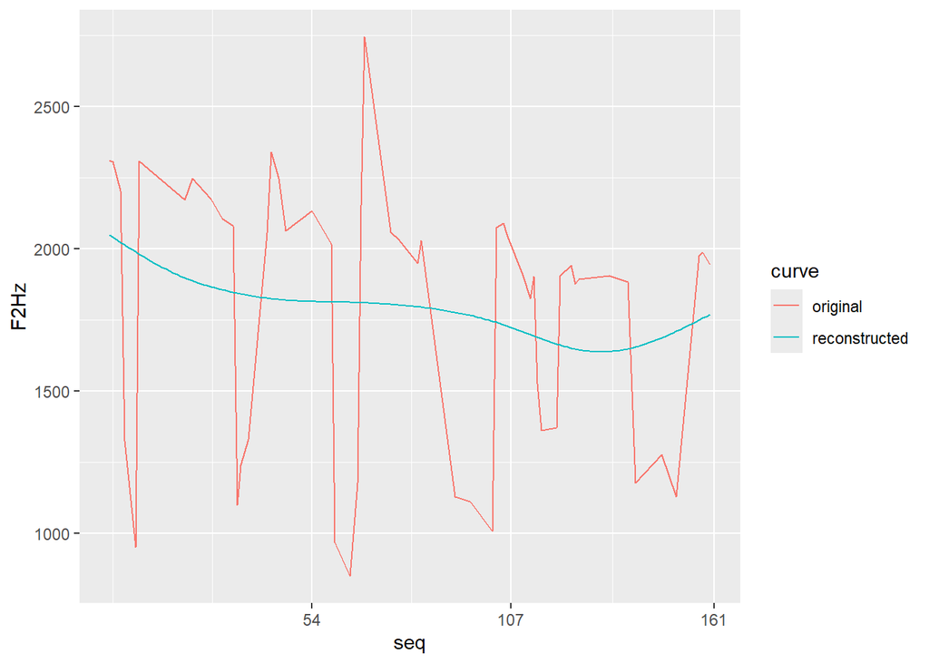

```r
orig_curve <- funF2[1] %>% funData2long1(time = "seq",value = "F2Hz")
rec_curve <- (fpcaF2$mu + fpcaF2$scores[1,1] * fpcaF2$functions[1] +
                fpcaF2$scores[1,2] * fpcaF2$functions[2]) %>% funData2long1(time = "seq", value = "F2Hz")
# join the curves into one long format tibble and plot
bind_rows(orig_curve %>% mutate(curve = "original"),
          rec_curve %>% mutate(curve = "reconstructed")) %>%
  ggplot(aes(seq, F2Hz, color = curve)) +
  scale_x_continuous(breaks = c(54, 107, 161))+
  geom_line()
```

Fit a regression model on s1

```r
#model for s1
s1mod <- lm (s1 ~ BB, data = PCscores)
emmeans(s1mod, pairwise ~BB)
```

```
## $emmeans
##  BB emmean  SE df lower.CL upper.CL
##  BB   1350 330 52      688     2013
##  NB  -1430 343 52    -2118     -743
##
## Confidence level used: 0.95
##
## $contrasts
##  contrast estimate  SE df t.ratio p.value
##  BB - NB      2780 476 52   5.844 <0.0001
```

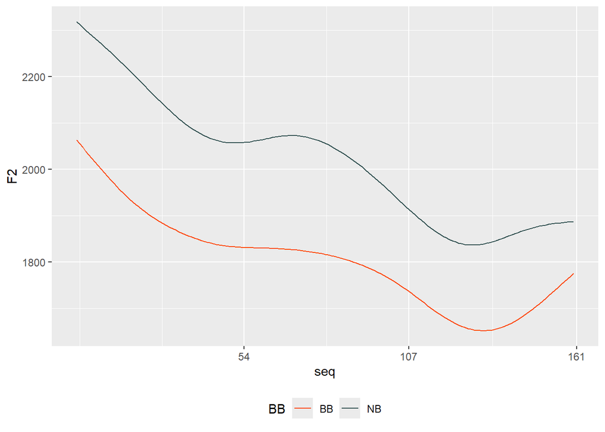

```r
#reconstruct predicted curves
emm <- emmeans (s1mod, pairwise ~ BB) $emmeans %>%
  as_tibble() %>%
  select(BB, emmean) %>%
  rename(s1 = emmean)

predCurvess1 <- emm %>%
  group_by(BB) %>%
  reframe(funData2long1(fpcaF2$mu + s1 * fpcaF2$functions[1])) %>%
  rename(seq = time, F2 = value)

ggplot(predCurvess1) +
  aes(seq, F2, color = BB)+
  geom_line()+
  scale_color_manual(values = Category.colors) +
  scale_x_continuous(breaks = c(54, 107, 161))+
  #mytheme +
  theme(legend.position = "bottom")
```

linear model on PC scores

```r
s1lm <- lm(s1 ~  BB * AF + gender, data = PCscores)
summary(s1lm)
```

```
##
## Call:
## lm(formula = s1 ~ BB * AF + gender, data = PCscores)
##
## Residuals:
##     Min      1Q  Median      3Q     Max
## -2578.5  -835.0    88.0   973.4  3209.4
##
## Coefficients:
##             Estimate Std. Error t value Pr(>|t|)
## (Intercept)   1033.6      366.2   2.823  0.00687 **
## BBNB         -2902.0      501.4  -5.788 4.96e-07 ***
## AFMN          -472.3      509.9  -0.926  0.35879
## genderM       2999.9      496.7   6.040 2.03e-07 ***
## BBNB:AFMN      425.2      721.4   0.589  0.55828
## ---
## Signif. codes:  0 '***' 0.001 '**' 0.01 '*' 0.05 '.' 0.1 ' ' 1
##
## Residual standard error: 1322 on 49 degrees of freedom
## Multiple R-squared:  0.6741, Adjusted R-squared:  0.6475
## F-statistic: 25.34 on 4 and 49 DF,  p-value: 2.057e-11
```

Plot the mean curve, then add one SD of s1 to it, on top of it, substract an SD of S1, to see what the first PC does

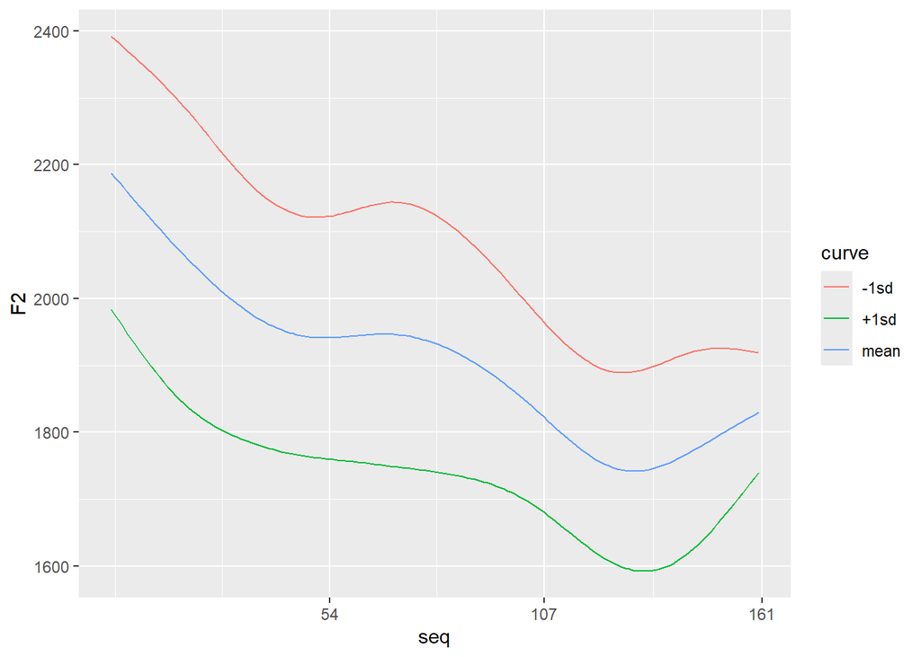

```r
#the mean curve
meancurve<- fpcaF2$mu %>% funData2long1(time = "seq", value = "F2") #%>% ggplot() +
  #aes(x = seq, y = F2) +
  #scale_x_continuous(breaks = c(54, 107, 161))+
  #geom_line()

#the mean curve with 1sd of s1 added
#plus1sdcurve <- fpcaF2$mu %>%funData2long1(time = "seq", value = "F2") %>%
  #mutate(F2 = F2 + sd(PCscores$s1))#%>% ggplot() +
  #aes(x = seq, y = F2) +
  #scale_x_continuous(breaks = c(54, 107, 161))+
  #geom_line()


sd1 <- fpcaF2$mu + 1*sd(PCscores$s1)*fpcaF2$functions[1]

plus1sdcurve <- sd1%>% funData2long1(time = "seq", value = "F2")

sd_1 <- fpcaF2$mu - 1*sd(PCscores$s1)*fpcaF2$functions[1]

minus1sdcurve <- sd_1%>% funData2long1(time = "seq", value = "F2")

# join the curves into one long format tibble and plot
bind_rows(meancurve %>% mutate(curve = "mean"),
          plus1sdcurve %>% mutate(curve = "+1sd"),
          minus1sdcurve %>% mutate(curve = "-1sd")) %>%
  ggplot(aes(seq, F2, color = curve)) +
  scale_x_continuous(breaks = c(54, 107, 161))+
  geom_line()
```

```r
#maybe it shouldn't be the mean curve? Check Gubian
```